# Vegetation drivers of moth assemblages within a tropical agricultural landscape

Aura Alonso-Rodriguez, Lily Shapiro and Ben Camber

12/03/2019

# Introduction

Land use change, and specifically agricultural expansion, is recognized globally as one of the major drivers of biodiversity loss. The expansion of African oil palm is specifically threatening, since the tropical areas suitable for oil palm are particularly rich in biodiversity and endemism. There is vast evidence of the severe impacts of oil palm expansion in Southeast Asia, where more than 85% of oil palm is cultivated, mostly by means of primary and secondary forest deforestation. Yet due to increasing food and biodiesel demands, oil palm is becoming a major threat in the Neotropics as well. Countries like Costa Rica, Colombia, Guatemala and Brazil, are experiencing increasing land conversion to oil palm, turning previously heterogeneous agricultural matrices into extensive monocultures that support significantly less biodiversity.

The expansion of African oil palm plantations in the Neotropics represents an immense challenge to the conservation of tropical biodiversity. In particular, insects in and around these plantations are easily disturbed by associated deforestation and increased use of agrochemicals. Their complex life cycles and trophic specificity are often ill-suited for large spatial-scale changes in canopy cover, plant species diversity, and forest structure. Conservation efforts in these threatened ecosystems can be more efficient and effective by understanding the complex ecological interactions that occur within them. Therefore, isolating important variables such as the most vulnerable life stage of an endangered species, the most ecotoxic pollutants contaminating a wetland, or the least resilient taxon in a disturbed ecosystem is critical to making useful change.

The South Pacific region of Costa Rica has grown in oil palm area during the last two decades. Evidence has already shown significant decreases in amphibians, reptiles, bats and insect diversity within these plantations, when compared to adjacent primary forests. In Alonso-Rodriguez et al. (2017), moth assemblages were seen to severely degrade in oil palm plantations when compared to primary and young secondary forests. Two moth taxa (Geometridae and Erebidae-Arctiinae, Lepidoptera) showed similar distributions along the disturbance gradient, which was partially explained by plant diversity and vegetation structure. However, which vegetation parameters had a bigger influence on observed distribution patterns and how they differ between moth taxa was not further explored by the authors.

Geometridae and Arctiinae share much of their ranges worldwide, but have very different life history strategies. Geometridae larval fitness is largely derived from their highly effective mimicry of leaves and twigs. On the other hand, Arctiinae larvae are often conspicuous or aposematic and have formidable spines or urticating hairs for defense against a wide variety of predators. The adults of these moth taxa have life histories that differ in a similar way; Geometridae are poor fliers and mimic tree bark, while Arctiinae are strong fliers and mimic wasps or possess threatening coloration. Geometridae are also known for preferring woody plant hosts, while there is a wide variety of host plant preferences within Arctiinae. Taking into account the differences in life history between geometrid and arctiine moths, their responses to structural and floristic vegetation features could help us better explore the potential of predicting diversity and turnover rates of these groups in human-dominated landscapes.

In this study, we ask the following questions: 1) Are structural or floristic features superior predictors of moth species diversity within a habitat disturbance gradient? and 2) Are responses similar in the two moth groups, despite some major differences in life-history traits of these moth taxa? We predict that modelling will reveal that vegetation variables will have drastically different effects on the success of these taxa. Establishing that superficially similar taxa have inherently different responses to disturbance is crucial for informing conservation policy not only in the case of Geometridae and Arctiinae, but in many other cryptic or non-charismatic taxa worldwide.

# Methods

From February to July of 2013, Alonso-Rodriguez et al. (2017) surveyed moth assemblages at 20 sites in the Gulfo Dolce region in southwestern Costa Rica. Study sites were selected in 4 of the dominant habitat types of the region - Forest Interior (FI), Forest Margin (FM), Young Secondary Forest (YSF) and Oil Palm Plantations (OPP) - with 5 replicates per habitat type. Using the vegan package in R, we calculated Fisher’s Alpha diversity index for the collected Geometrid and Erebidae-Arctiinae moths at each site.

The authors also measured a variety of forest structural and vegetation parameters in each site. The following represents a list of the measured parameters, which we considered as potential independent variables for our models.

- Tree species composition (abundance matrix)
- Plant species richness
- Vegetation density
- Plant species diversity (Fisher’s alpha index)
- Understory density
- Understory complexity
- Undergrowth cover
- Vertical complexity
- Canopy cover
- Tree basal area

Because the tree species composition matrix could not be feasibly included in our models, we used non-metric multidimensional scaling (NMDS) with Bray-Curtis distance to capture variation of plant species composition in each site. We then extracted the coordinates of each site from the ordination plot (NMDS axes 1 and 2) to be used as a proxy for plant species composition. These analyses were conducted with the vegan package in R.

We grouped the independent variables mentioned above as either structural or floristic parameters. In order to select the final parameters to keep in our structural and floristic models, we first used the cor and corrplot functions in R to evaluate which variables were autocorrelated (higher than 0.6 correlation coefficient). From correlated variables, we decided which ones to keep based on published literature on moth biology and life history. Our final models were as follows:

*Structural Models:*

Geometrid alpha diversity ~ understory complexity + canopy cover + vertical complexity

Arctiine alpha diversity ~ understory complexity + canopy cover + vertical complexity

*Floristic Models:*

Geometrid alpha diversity ~ NMDS1 + NMDS2 + plant species diversity + vegetation density

Arctiine alpha diversity ~ NMDS1 + NMDS2 + plant species diversity + vegetation density

We examined the distribution of the moth diversity using the Shapiro-Wilk normality test and the R descdist function (fitdistrplus package, Comprehensive R Archive Network). Due to the distribution of the data, we used linear mixed (LMER) models for Arctiinae and generalized mixed (GLMER) models for Geometridae. LMER and GLMER revealed which components of the models were significant predictors of Geometridae and Arctiinae diversity. LMER and GLMER were sourced from the lme4 R package (CRAN), while p values for the predictiveness of the vegetation parameters were generated by the lmeTest package (CRAN).

In our models, we considered the Habitat category as a random effect, since we were not interested in evaluating how this affected moth diversity. Rather, our main interest was in evaluating how the variation in moth diversity is reflected by the chosen floristic and structural vegetation parameters. Since moonlight has shown to affect light trap catchments of flying insects, we also added average moonlight (fraction of the moon illuminated) as a random factor. Moonlight data was extracted from the United States Naval Observatory (http://aa.usno.navy.mil/data/docs/MoonFraction.php) per sampling date, and then averaged for each site. Finally, we used AIC (Akaike’s Information Criterion) to compare the strength of the structural and floristic models for geometrids and arctiines separately.

# Results

## Calculating Fisher’s alpha Diversity Index for Geometridae and Arctiinae

## Extracting the NMDS axis coordinates for the plant species matrix, to be used as proxy for plant species composition

```
## Wisconsin double standardization
## *** No convergence -- monoMDS stopping criteria:
##     28: no. of iterations >= maxit
##     72: stress ratio > sratmax
```

```
##
## Call:
## metaMDS(comm = plants, distance = "bray", k = 3, trymax = 100)
##
## global Multidimensional Scaling using monoMDS
##
## Data:     wisconsin(plants)
## Distance: bray
##
## Dimensions: 3
## Stress:     0.05298466
## Stress type 1, weak ties
## No convergent solutions - best solution after 100 tries
## Scaling: centring, PC rotation, halfchange scaling
## Species: expanded scores based on 'wisconsin(plants)'
```

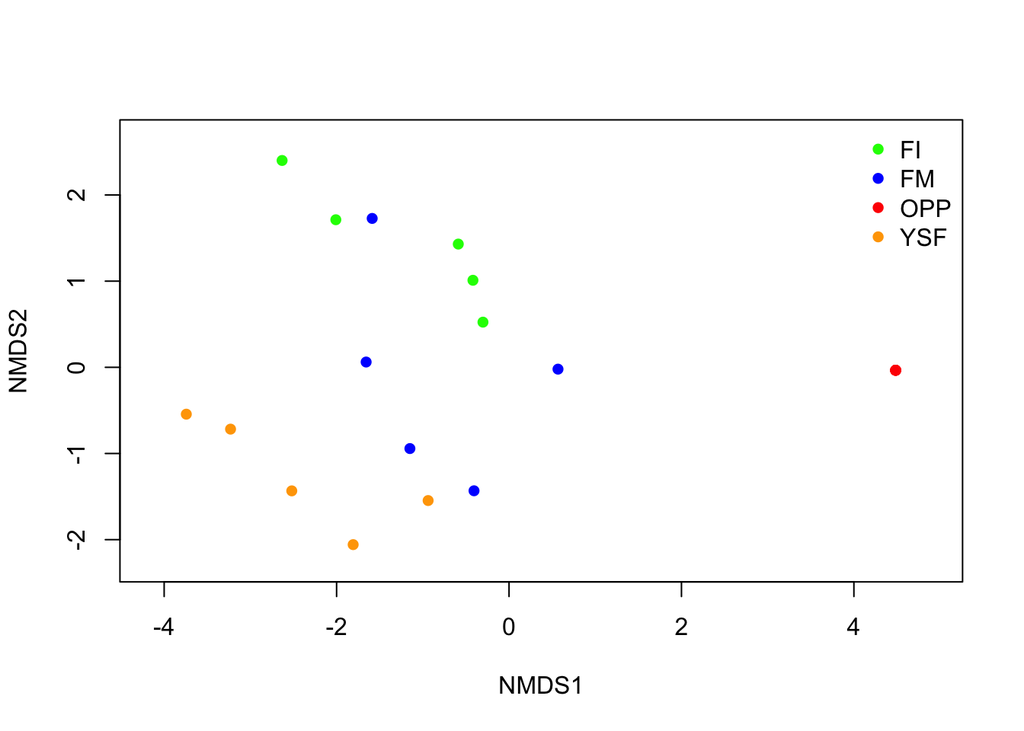

## Pearson correlation coefficients between all independent variables

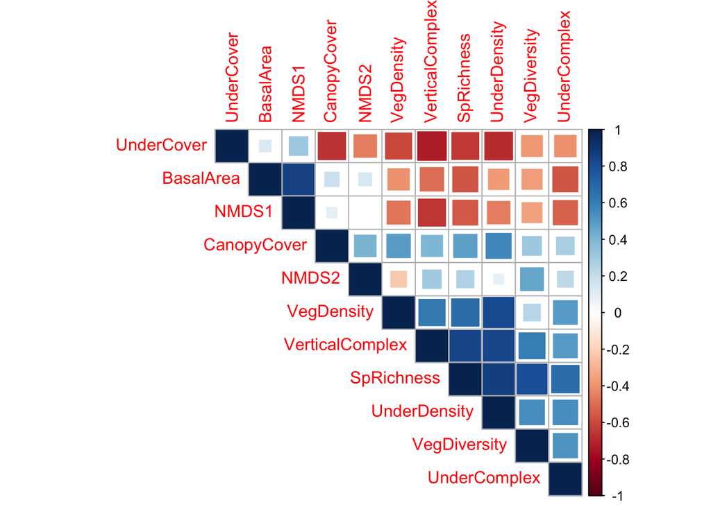

We used the Pearson coefficients to determine correlation between the vegetation parameters. We determined that a floristic model could safely include the following parameters since they lack strong correlations: plant species diversity, vegetation density, and a plant species composition matrix (NMDS1 and NMDS2). We also found that a structural model could include the following parameters: understory complexity, canopy cover, and vertical complexity.

## Modeling alpha diversity of Geometridae and Arctiinae against structural and floristic variables

Results from our generalized mixed-effects model (Geometridae) and linear mixed-effects model (Arctiinae) showed similar responses of both moth groups to floristic and structural parameters. All models and graphs of the relationship between moth diversity and each independent variable included in the models are shown below.

### Evaluating distribution of moth diversity data

```
##
##  Shapiro-Wilk normality test
##
## data:  covar_moth$Geometrid_FisherIndex
## W = 0.87764, p-value = 0.01605
```

```
##
##  Shapiro-Wilk normality test
##
## data:  covar_moth$Arctiine_FisherIndex
## W = 0.9299, p-value = 0.1537
```

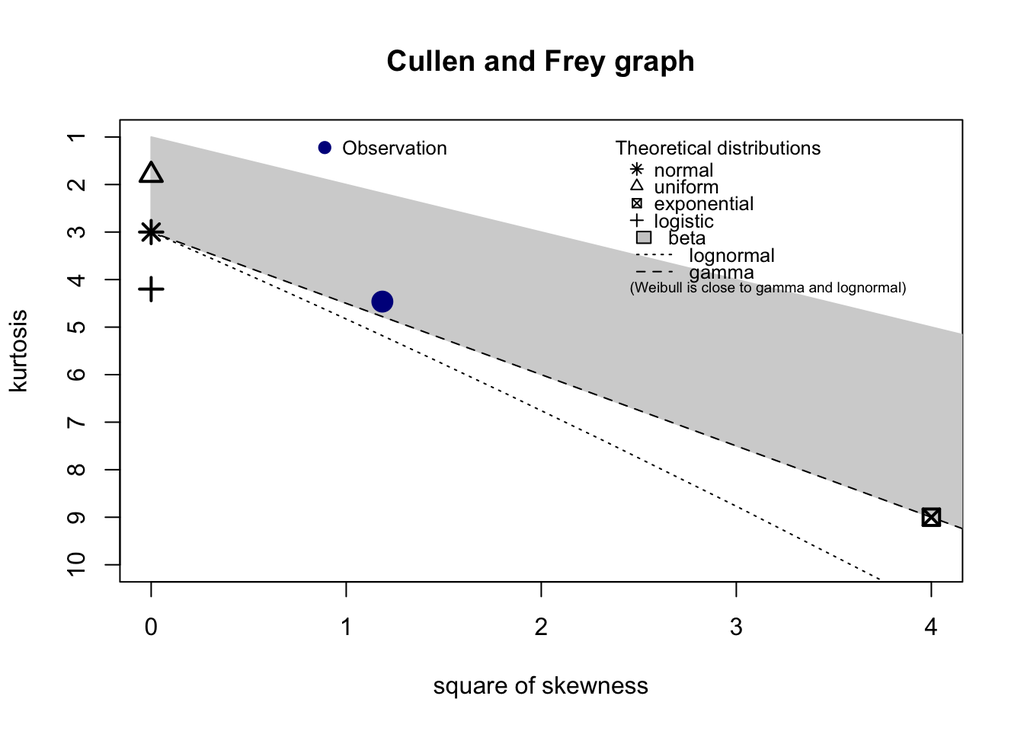

```
## summary statistics
## ------
## min:  6.11273   max:  73.17881
## median:  24.63236
## mean:  24.66262
## estimated sd:  17.7614
## estimated skewness:  1.088706
## estimated kurtosis:  4.46317
```

The Shapiro Wilk Test revealed that the Arctiinae diversity data is normally distributed. So, we used linear mixed models (lmer function in R) for all Arctiinae models, which assume that the data is normally distributed (Gaussian distribution). For Geometridae however, Shapiro-Wilks test revealed that the data is not normally distributed, and the descdist function identified it as having a gamma distribution. For this reason, we used generalized mixed models (glmer function in R) for all Geometridae models, which allow for specifying the distribution of data with non-Gaussian distributions.

### Geometridae diversity against structural parameters

```
## Generalized linear mixed model fit by maximum likelihood (Laplace
##   Approximation) [glmerMod]
##  Family: Gamma  ( log )
## Formula:
## Geometrid_FisherIndex ~ UnderComplex + CanopyCover + VerticalComplex +
##     (1 | Moonlight) + (1 | Habitat)
##    Data: covar_moth
##
##      AIC      BIC   logLik deviance df.resid
##    165.0    172.0    -75.5    151.0       13
##
## Scaled residuals:
##     Min      1Q  Median      3Q     Max
## -1.5388 -0.4993 -0.1074  0.5415  1.6999
##
## Random effects:
##  Groups    Name        Variance Std.Dev.
##  Moonlight (Intercept) 0.05608  0.2368
##  Habitat   (Intercept) 0.23188  0.4815
##  Residual              0.20354  0.4512
## Number of obs: 20, groups:  Moonlight, 8; Habitat, 4
##
## Fixed effects:
##                  Estimate Std. Error t value Pr(>|z|)
## (Intercept)      3.189614   0.934889   3.412 0.000645 ***
## UnderComplex     0.114630   0.560124   0.205 0.837845
## CanopyCover     -0.003863   0.014314  -0.270 0.787277
## VerticalComplex -0.080419   0.899518  -0.089 0.928762
## ---
## Signif. codes:  0 '***' 0.001 '**' 0.01 '*' 0.05 '.' 0.1 ' ' 1
##
## Correlation of Fixed Effects:
##             (Intr) UndrCm CnpyCv
## UnderComplx -0.420
## CanopyCover -0.108 -0.662
## VertclCmplx -0.468  0.742 -0.742
```

[output not shown]

[output not shown]

[output not shown]

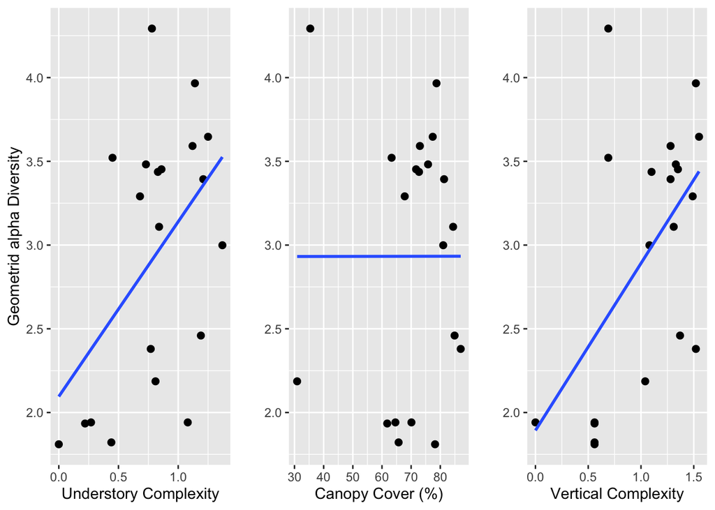

The geometrid structural model displayed no significant correlation between the listed structural parameters (understory complexity, canopy cover, and vertical complexity), showing that geometrid diversity is likely not a function of structural forest variables in these study sites.

### Arctiinae diversity against structural parameters

```
## Linear mixed model fit by REML. t-tests use Satterthwaite's method [
## lmerModLmerTest]
## Formula:
## Arctiine_FisherIndex ~ UnderComplex + CanopyCover + VerticalComplex +
##     (1 | Moonlight) + (1 | Habitat)
##    Data: covar_moth
##
## REML criterion at convergence: 119
##
## Scaled residuals:
##     Min      1Q  Median      3Q     Max
## -1.0052 -0.5947 -0.2638  0.4222  1.6753
##
## Random effects:
##  Groups    Name        Variance Std.Dev.
##  Moonlight (Intercept)  5.941   2.437
##  Habitat   (Intercept) 97.289   9.864
##  Residual              24.388   4.938
## Number of obs: 20, groups:  Moonlight, 8; Habitat, 4
##
## Fixed effects:
##                 Estimate Std. Error     df t value Pr(>|t|)
## (Intercept)       31.985     10.426  8.940   3.068   0.0135 *
## UnderComplex       2.600      4.580 12.263   0.568   0.5805
## CanopyCover       -0.150      0.107  8.499  -1.401   0.1966
## VerticalComplex   -7.502      6.208 13.264  -1.208   0.2480
## ---
## Signif. codes:  0 '***' 0.001 '**' 0.01 '*' 0.05 '.' 0.1 ' ' 1
##
## Correlation of Fixed Effects:
##             (Intr) UndrCm CnpyCv
## UnderComplx -0.398
## CanopyCover -0.432 -0.226
## VertclCmplx -0.494  0.340 -0.341
```

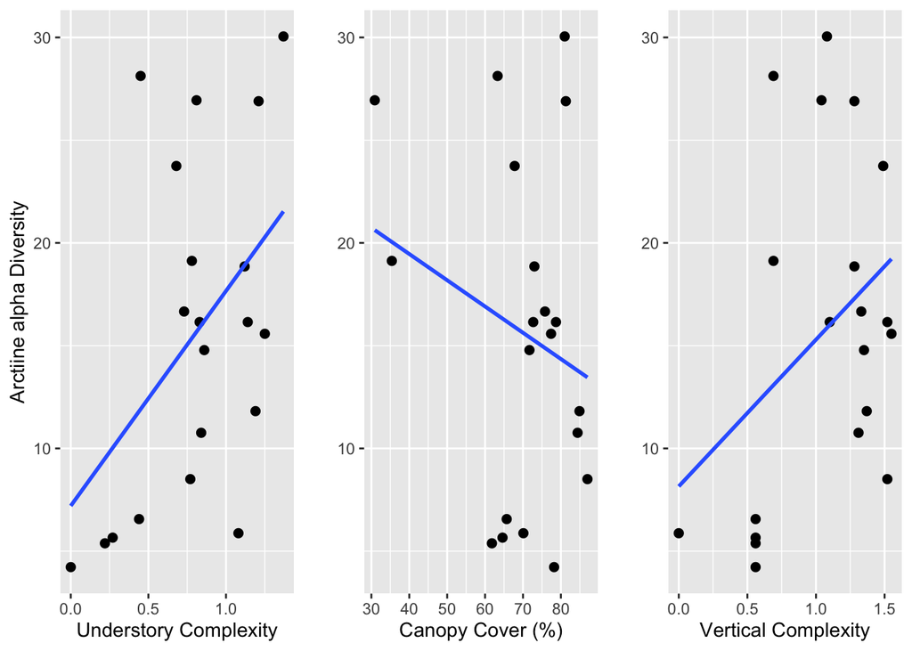

The arctiine structural model showed little to no relationship between the aforementioned structural variables and alpha diversity within this clade. However, the large output value for habitat as a controlled random effect (97.289) suggests this component plays a significant role in dictating patterns of arctiine diversity.

### Geometridae diversity against floristic parameters

```
## Generalized linear mixed model fit by maximum likelihood (Laplace
##   Approximation) [glmerMod]
##  Family: Gamma  ( log )
## Formula:
## Geometrid_FisherIndex ~ VegDiversity + VegDensity + NMDS1 + NMDS2 +
##     (1 | Moonlight) + (1 | Habitat)
##    Data: covar_moth
##
##      AIC      BIC   logLik deviance df.resid
##    158.2    166.1    -71.1    142.2       12
##
## Scaled residuals:
##     Min      1Q  Median      3Q     Max
## -1.4570 -0.6296 -0.1251  0.5783  1.6631
##
## Random effects:
##  Groups    Name        Variance Std.Dev.
##  Moonlight (Intercept) 0.10413  0.3227
##  Habitat   (Intercept) 0.02786  0.1669
##  Residual              0.14302  0.3782
## Number of obs: 20, groups:  Moonlight, 8; Habitat, 4
##
## Fixed effects:
##               Estimate Std. Error t value Pr(>|z|)
## (Intercept)   2.419119   0.308423   7.844 4.38e-15 ***
## VegDiversity  0.025024   0.007390   3.386 0.000709 ***
## VegDensity    0.002470   0.003797   0.650 0.515433
## NMDS1        -0.117604   0.059781  -1.967 0.049154 *
## NMDS2        -0.278201   0.123361  -2.255 0.024122 *
## ---
## Signif. codes:  0 '***' 0.001 '**' 0.01 '*' 0.05 '.' 0.1 ' ' 1
##
## Correlation of Fixed Effects:
##             (Intr) VgDvrs VgDnst NMDS1
## VegDiversty -0.361
## VegDensity  -0.464 -0.087
## NMDS1       -0.148  0.218  0.098
## NMDS2        0.204 -0.323 -0.100  0.242
```

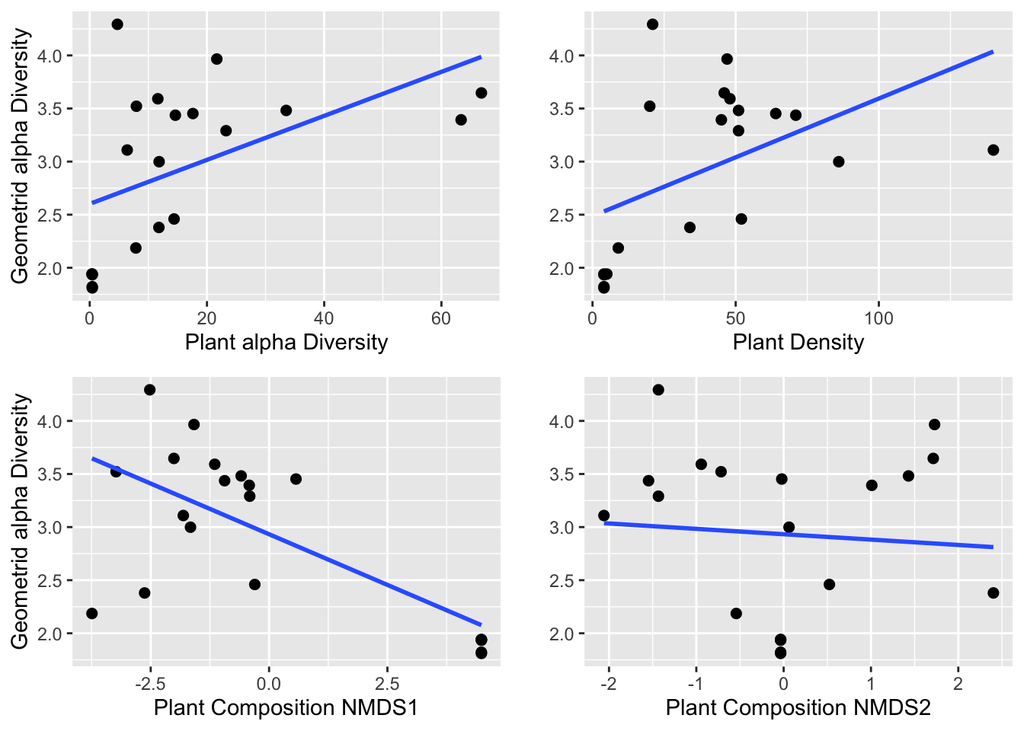

### Arctiinae diversity against floristic parameters

```
## boundary (singular) fit: see ?isSingular
```

```
## Linear mixed model fit by REML. t-tests use Satterthwaite's method [
## lmerModLmerTest]
## Formula:
## Arctiine_FisherIndex ~ VegDiversity + VegDensity + NMDS1 + NMDS2 +
##     (1 | Moonlight) + (1 | Habitat)
##    Data: covar_moth
##
## REML criterion at convergence: 121.9
##
## Scaled residuals:
##      Min       1Q   Median       3Q      Max
## -1.40414 -0.44870 -0.08145  0.24619  2.45010
##
## Random effects:
##  Groups    Name        Variance Std.Dev.
##  Moonlight (Intercept)  0.00    0.000
##  Habitat   (Intercept) 10.56    3.250
##  Residual              25.19    5.019
## Number of obs: 20, groups:  Moonlight, 8; Habitat, 4
##
## Fixed effects:
##              Estimate Std. Error       df t value Pr(>|t|)
## (Intercept)  15.64545    2.79629  4.74247   5.595  0.00298 **
## VegDiversity  0.17847    0.08285 14.98347   2.154  0.04791 *
## VegDensity   -0.07210    0.04304 14.93753  -1.675  0.11471
## NMDS1        -2.14775    0.68629  3.61846  -3.130  0.04037 *
## NMDS2        -2.67626    1.43069 10.22278  -1.871  0.09027 .
## ---
## Signif. codes:  0 '***' 0.001 '**' 0.01 '*' 0.05 '.' 0.1 ' ' 1
##
## Correlation of Fixed Effects:
##             (Intr) VgDvrs VgDnst NMDS1
## VegDiversty -0.360
## VegDensity  -0.534 -0.183
## NMDS1       -0.180  0.132  0.190
## NMDS2       -0.093 -0.276  0.360  0.166
## convergence code: 0
## boundary (singular) fit: see ?isSingular
```

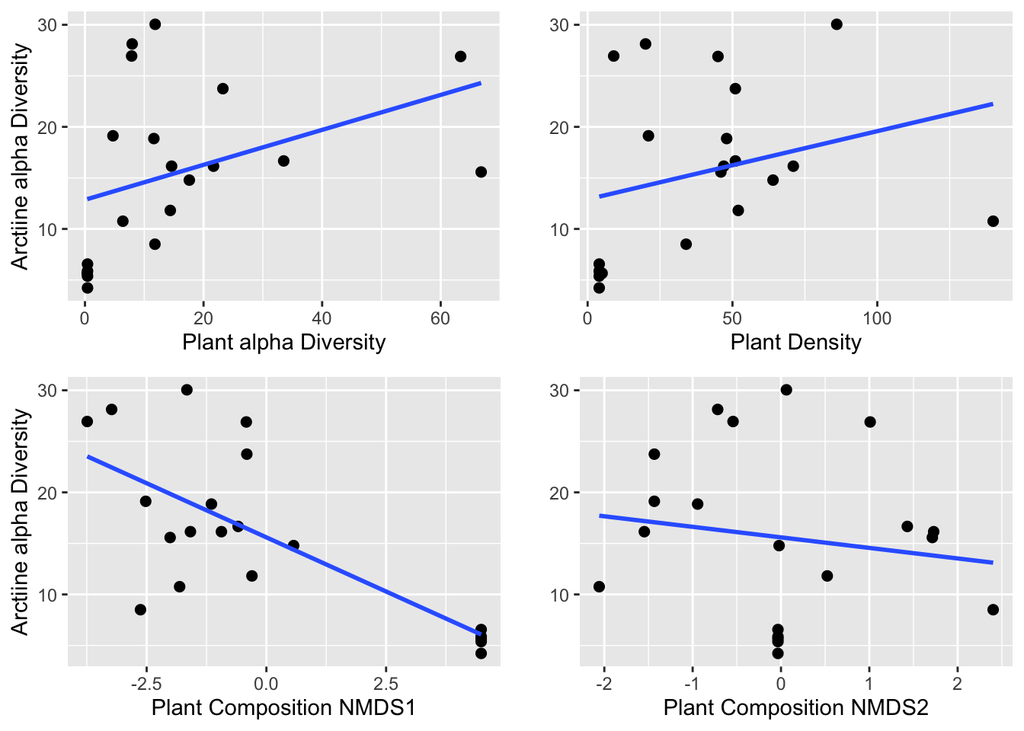

### Using AIC to compare the floristic and structural models for each moth group

|  | df | AIC |
| --- | --- | --- |
| Geometrid.structural | 7 | 165.0320 |
| Geometrid.floristic | 8 | 158.1526 |

|  | df | AIC |
| --- | --- | --- |
| Arctiid.structural | 7 | 132.9644 |
| Arctiid.floristic | 8 | 137.8816 |

# Discussion

# References

Alonso-Rodríguez, A. M., Finegan, B., & Fiedler, K. (2017). Neotropical moth assemblages degrade due to oil palm expansion. Biodiversity and Conservation, 26(10), 2295-2326.

Axmacher, J. C., Brehm, G., Hemp, A., Tünte, H., Lyaruu, H. V., Müller‐Hohenstein, K., & Fiedler, K. (2009). Determinants of diversity in afrotropical herbivorous insects (Lepidoptera: Geometridae): plant diversity, vegetation structure or abiotic factors?. Journal of Biogeography, 36(2), 337-349.

Beck, J., Brehm, G., & Fiedler, K. (2011). Links between the environment, abundance and diversity of Andean moths. Biotropica, 43(2), 208-217.

Beck, J. A. N., Schulze, C. H., Linsenmair, K. E., & Fiedler, K. (2002). From forest to farmland: diversity of geometrid moths along two habitat gradients on Borneo. Journal of tropical ecology, 18(1), 33-51.

Fuentes-Montemayor, E., Goulson, D., Cavin, L., Wallace, J. M., & Park, K. J. (2012). Factors influencing moth assemblages in woodland fragments on farmland: Implications for woodland management and creation schemes. Biological Conservation, 153, 265-275.

Gray, R. E., Slade, E. M., Chung, A. Y., & Lewis, O. T. (2019). Movement of moths through riparian reserves within oil palm plantations. bioRxiv, 204990.

Hilt, N., & Fiedler, K. (2005). Diversity and composition of Arctiidae moth ensembles along a successional gradient in the Ecuadorian Andes. Diversity and Distributions, 11(5), 387-398.